# FordGoBike_Part2

## by Emuejevoke Eshemitan

## Investigation Overview

For this presentation, we would be visualising plots that shows the follwoing insights

- People tends to ride more frequently during the weekdays than weekends
- Majority of the people riding the bikes are Male
- Customers takes longer rides compared to subscribers
- Irrespective of the gender, the durations taper off as a person gets older.

## Dataset Overview

> This data set includes information about individual rides made in a bike-sharing system covering the greater San Francisco Bay area for the month of February 2019. For this project, the data was made available by Udacity with this link [dataset](https://video.udacity-data.com/topher/2020/October/5f91cf38_201902-fordgobike-tripdata/201902-fordgobike-tripdata.csv)

**Note:The dataset used for the presentation is the dataset created after cleaning which structured to have 174,952 observations with 20 features.**

## Ride Frequency per Day of the Week

> This helps to visualize the first key inisght: "People tends to ride more frequently during the weekdays than weekends"

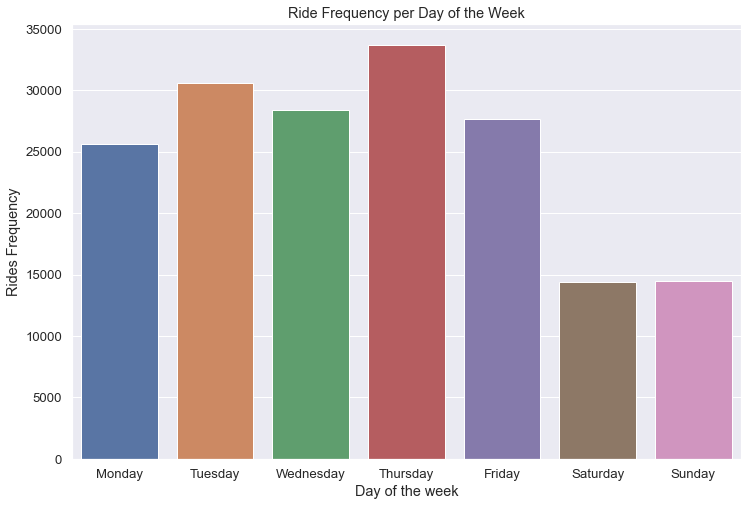

## Number of Bike Riders per Gender

> This helps to visualize the 2nd key inisght: "Majority of the people riding the bikes are Male"

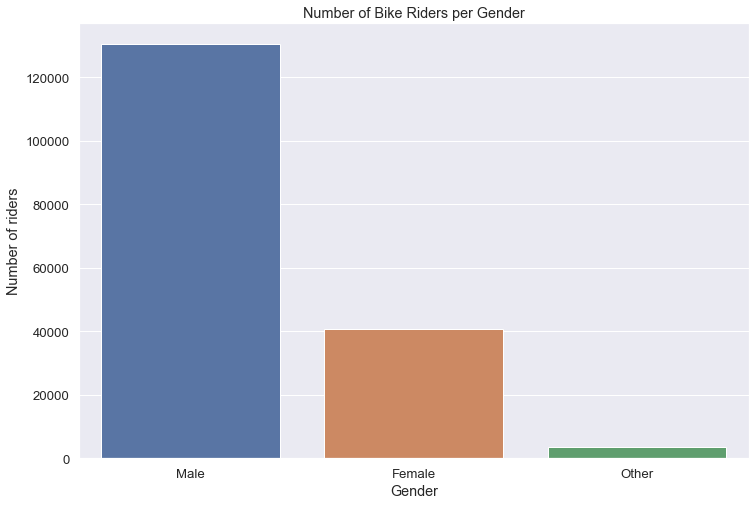

## Ride Duration of Customers and Subscribers

> This helps to visualize the 3rd key inisght: "Customers takes longer rides compared to subscribers"

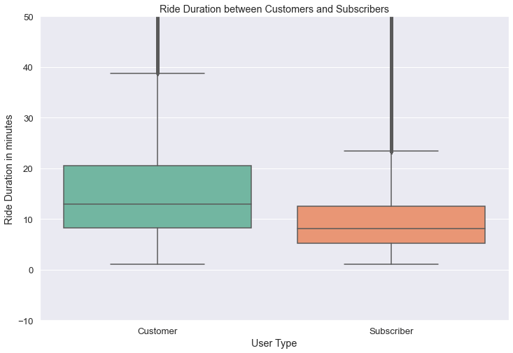

## Ride Duration Across Ages and Genders

> This helps to visualize the 4th key inisght: "Irrespective of the gender, the durations taper off as a person gets older."

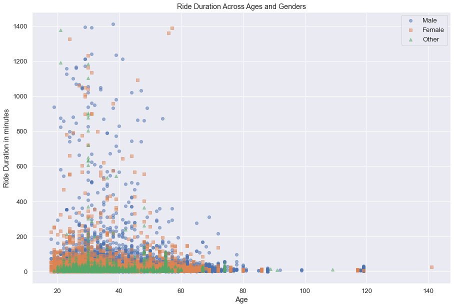